# Analysing EEG data with Bayesian LMMs and distributional regression models

Maria Korochkina

Last update: 27 March, 2023

```r
rm(list=ls())

library("openxlsx")
library("Rmisc")
library("tidyverse")
library("MASS")
library("scales")
library("rstan")
options(mc.cores = parallel::detectCores())
rstan_options(auto_write = TRUE)
# bridgesampling has to be loaded before brms for brm(bf()) to work
library("bridgesampling")
library("brms")
library("designr")
library("reshape")
library("RColorBrewer")
library("ggpubr")
library("bayesplot")
library("EnvStats")
library("purrr")
library("magrittr")
library("cowplot")
library("ggdist")
library("MCMCglmm")
```

# Load and inspect data

```r
data <- read.csv("Data.csv", check.names = F)

# make sure relevant vars are factors
data$Subj <- factor(data$Subj)
data$Word <- factor(data$Word)

data$TargetSet <- factor(data$TargetSet)
data$Condition <- factor(data$Condition)
```

- The data comes from a continuous primed lexical decision task (in English); it has been cleaned and contains data only for targets with correct responses and good epochs
- We will be analysing averaged N400 amplitudes for semantically related and unrelated targets
- N400 spatiotemporal window was defined as follows:
  - Times: 300-500ms
  - Electrodes: C5, C3, C1, Cz, C2, C4, C4, C6, CP5, CP3, CP1, CPz, CP2, CP4, CP6, P7, P5, P3, P1, Pz, P2, P4, P6, P8
- NOTE THAT SOME MODELS MAY TAKE A VERY LONG TIME TO RUN

## Data distribution per condition

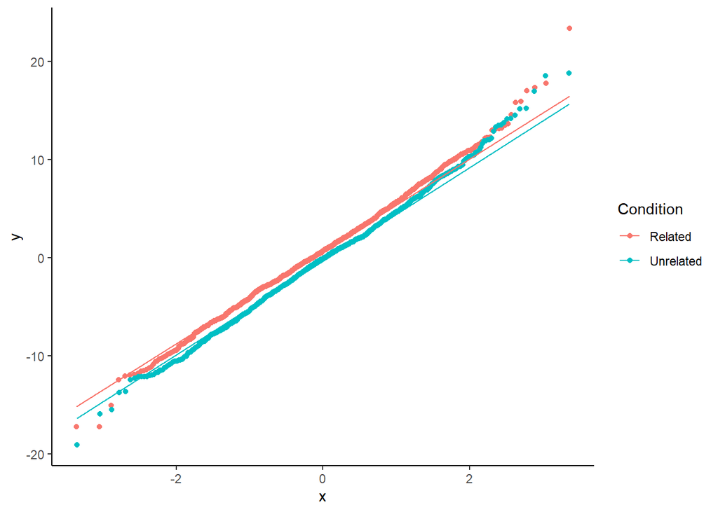

```r
data %>%
  ggplot(aes(sample = N400avg, color = Condition)) +
  theme_classic() + stat_qq() + stat_qq_line()
```

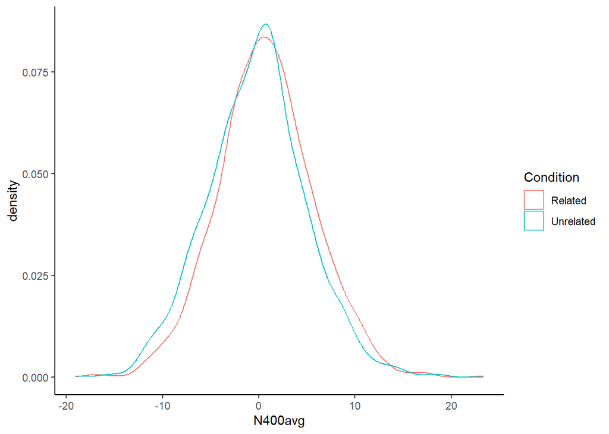

```r
data %>%
  ggplot(aes(x = N400avg, color = Condition)) +
  geom_density() + theme_classic()
```

## Summarise data

```r
sum_ampl <- data %>%
  dplyr::group_by(Subj, Condition) %>%
  dplyr::summarize(meanN400 = mean(N400avg))

(Amplitude_N400 <- summarySE(sum_ampl, measurevar = c("meanN400"),
                              groupvars = "Condition",
                       na.rm = FALSE, conf.interval = .95))
```

```
##   Condition  N   meanN400       sd        se        ci
## 1   Related 71  0.7459588 1.696248 0.2013076 0.4014954
## 2 Unrelated 71 -0.2623582 1.938119 0.2300124 0.4587452
```

## Plot data

Prepare for plotting

```r
# extract relevant cols
Info <- data[, 1:24]

N400 <- data %>%
  dplyr::select(starts_with("N400"))

dataN400 <- cbind(Info,N400)
dataN400 <- dplyr::rename(dataN400, AvgAmpl = N400avg)

# reshape
dataN400long <- dataN400 %>%
  pivot_longer(cols = starts_with("N400_"), names_to = "Time", values_to = "Amplitude") %>%
  separate(Time, c("N400", "Time1", "Time2"), sep = "_")
dataN400long = dataN400long[,-26]

dataN400long$Time1 <- as.numeric(dataN400long$Time1)
dataN400long$Time2 <- as.numeric(dataN400long$Time2)

# compute the average of all trials per subj per cond per time point
dataN400means <- dataN400long %>%
  dplyr::group_by(Subj, Condition, Time1) %>%
  dplyr::summarize(meanAmpl = mean(Amplitude))

# compute SEs
dataN400meansSE <- dataN400means %>%
split(.$Time1) %>%
  purrr::map(~summarySE(data = ., measurevar = "meanAmpl",
                       groupvars = "Condition",
                                      na.rm = FALSE, conf.interval = .95))

# convert dataN400meansSE, a list of data frames,
# into a single data frame summarising the data at each time point
# after removing between-subject variability
dataN400CI <- purrr::map_df(dataN400meansSE, magrittr::extract) %>%
  mutate(Time1 = rep(unique(dataN400means$Time1), each = 2))
```

Plot

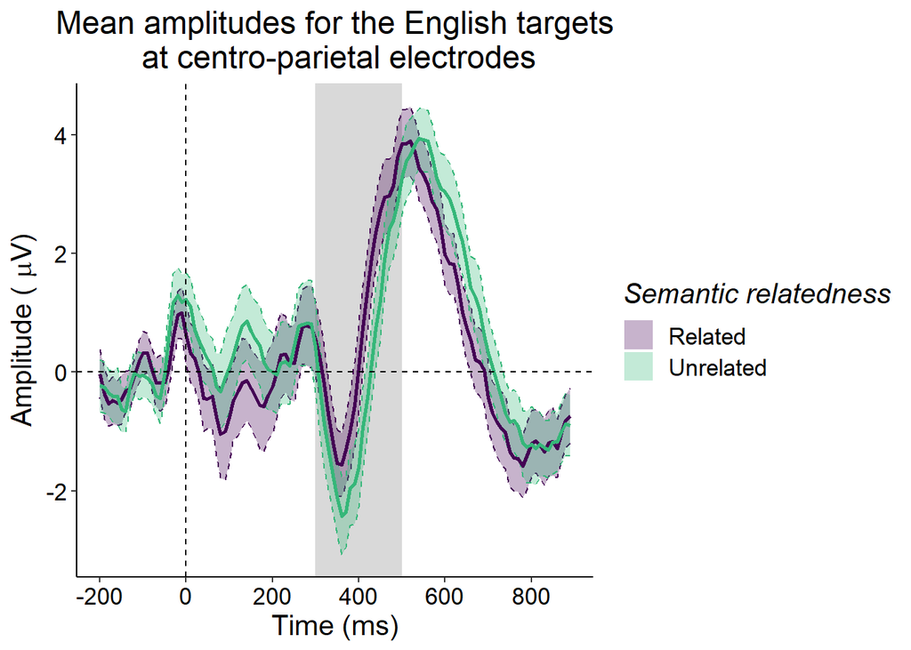

```r
(N400plot1 <- ggplot(dataN400means, aes(Time1, meanAmpl)) +
  annotate(geom = "rect", xmin = 300, xmax = 500, ymin = -Inf, ymax = Inf,
           fill = "black", alpha = 0.15) +
  geom_ribbon(data = dataN400CI, aes(ymin = meanAmpl-ci, ymax = meanAmpl+ci,
                                     fill = Condition, colour = Condition),
              linetype = "dashed", alpha = 0.3) +
  stat_summary(fun.y = mean, geom = "line", size = 1, aes(colour = Condition)) +
  theme_classic() +
  theme(axis.title.x = element_text(size = rel(1.4), colour = "black"),
        axis.title.y = element_text(size = rel(1.4), colour = "black"),
        panel.background = element_rect(colour = "white"),
        axis.text = element_text(size = rel(1.2), colour = "black"),
        legend.text = element_text(size = rel(1.2), colour = "black"),
        legend.title = element_text(size = rel(1.4), colour = "black", face = "italic"),
        plot.title = element_text(size = rel(1.6), hjust = 0.5),
        axis.line = element_line(colour = "black")) +
  ggtitle("Mean amplitudes for the English targets\n at centro-parietal electrodes") +
  labs(x = "Time (ms)",y = expression(paste("Amplitude ( ", mu,"V)")), colour = "") +
  geom_vline(xintercept = 0, linetype = "dashed") +
  geom_hline(yintercept = 0, linetype = "dashed") +
  scale_colour_manual(name = "Semantic relatedness",
                     labels = c("Related", "Unrelated"),
                     values = c("#440154FF", "#35B779FF")) + guides(colour = "none") +
  scale_fill_manual(name = "Semantic relatedness",
                    labels = c("Related", "Unrelated"),
                    values = c("#440154FF", "#35B779FF")) +
  scale_x_continuous(breaks = c(-200, 0, 200, 400, 600, 800)))
```

Plot with the difference wave

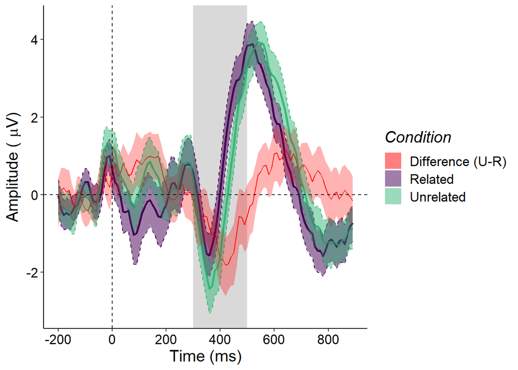

```r
dataN400Diff <- dataN400means %>%
  pivot_wider(names_from = Condition, values_from = meanAmpl) %>%
  dplyr::group_by(Subj, Time1) %>%
  dplyr::mutate(Diff = Unrelated - Related) %>%
  pivot_longer(cols = c("Related", "Unrelated", "Diff"), names_to = "Condition", values_to = "meanAmpl")

(N400plot2 <- ggplot(dataN400means, aes(Time1, meanAmpl)) +
  annotate(geom = "rect", xmin = 300, xmax = 500, ymin = -Inf, ymax = Inf,
           fill = "black", alpha = 0.15) +
  geom_ribbon(data = dataN400CI, aes(ymin = meanAmpl-ci,
                                     ymax = meanAmpl+ci,
                                     fill = Condition,
                                     colour = Condition),
              linetype = "dashed", alpha = 0.3) +
  stat_summary(fun.y = mean, geom = "line",
               size = 1, aes(colour = Condition)) +

  stat_summary(data = dataN400Diff, fun.y = mean,
               geom = "line",aes(colour = Condition)) +
  stat_summary(data = dataN400Diff, fun.data = mean_cl_boot,
               geom = "ribbon", alpha = 0.3, aes(fill = Condition)) +

  theme_classic() +
  theme(axis.title.x = element_text(size = rel(1.4), colour = "black"),
        axis.title.y = element_text(size = rel(1.4), colour = "black"),
        panel.background = element_rect(colour = "white"),
        axis.text = element_text(size = rel(1.2), colour = "black"),
        legend.text = element_text(size = rel(1.2), colour = "black"),
        legend.title = element_text(size = rel(1.4),
                                    colour = "black", face = "italic"),
        plot.title = element_text(size = rel(1.4), hjust = 0.5),
        axis.line = element_line(colour = "black")) +
  labs(x = "Time (ms)",
       y = expression(paste("Amplitude ( ", mu,"V)")), colour = "") +
  geom_vline(xintercept = 0, linetype = "dashed") +
  geom_hline(yintercept = 0, linetype = "dashed") +
  scale_colour_manual(name = "Condition",
                    labels = c("Difference (U-R)", "Related", "Unrelated"),
                    values = c("#FF0000", "#440154FF", "#35B779FF")) + guides(colour = "none") +
  scale_fill_manual(name = "Condition",
                    labels = c("Difference (U-R)", "Related", "Unrelated"),
                    values = c("#FF0000", "#440154FF", "#35B779FF")) +
  scale_x_continuous(breaks = c(-200, 0, 200, 400, 600, 800)))
```

Remove irrelevant columns

```r
dataN400 <- dataN400[, c(1:25)]
```

# Contrast coding

```r
# code Related as -.5 and Unrelated as .5
dataN400$cond <- ifelse(dataN400$Condition == "Related", -.5, 5)
```

# Select model

## Complete pooling model

$$signal_{n} = Normal(\alpha + Cond_{n}*\beta, \sigma)$$
where

- $signal$ is the mean amplitude in the N400 spatiotemporal window
- $n = 1,...,N$
- $N$ is the number of data points
- $Cond$ is the effect of semantic relatedness

This model assumes that all observations are independent, however, in our dataset, observations are grouped by subject.

## No pooling model

$$signal_{n} = Normal(\alpha_{subj[n]} + Cond_{n}*\beta_{subj[n]}, \sigma)$$
This model will estimate data separately for each subject (the subjects have no parameters in common except for sigma). This is likely to result in overfitting, i.e., individual noise will be considered useful information. We need to use the fact that all subjects did the same task.

## Uncorrelated varying intercepts and slopes for subjects

$$signal_{n} = Normal(\alpha + u_{subj[n],1} + Cond_{n}*(\beta +
u_{subj[n],2}), \sigma)$$
In this model, intercept and slope are the same for all subjects, but, for each subject, there are adjustments to the intercept ($u_{subj[n],1}$) and slope ($u_{subj[n],2}$). Importantly, the model assumes that these varying intercepts and slopes are independent. But could it be that subjects with more positive amplitudes show stronger/weaker effects?

## Correlated varying intercepts and slopes for subjects

The likelihood function remains identical to the model with uncorrelated varying intercepts and slopes:

$$signal_{n} = Normal(\alpha + u_{subj[n],1} + Cond_{n}*(\beta +
u_{subj[n],2}), \sigma)$$
But we now define a variance-covariance matrix for the varying intercepts and slopes, where the intercepts and slopes are assumed to come from a bivariate normal distribution.

$$\left(
\begin{array}{cc}
u_{i,1} \\
u_{i,2}
\end{array}
\right) \sim \left(Normal \left(
\begin{array} {cc}
0 \\
0
\end{array}
\right), \left[
\begin{array}{cc}
\sigma u_{i,1}^2 & \rho \sigma u_{i,1}\sigma u_{i,2} \\
\rho \sigma u_{i,1}\sigma u_{i,2} & \sigma u_{i,2}^2
\end{array}
\right]
\right)$$

where

$\rho$ is the correlation parameter.

## Correlated varying intercepts and slopes for subjects and items

Allow the parameters to vary across the items too!

$$signal_{n} = Normal(\alpha + u_{subj[n],1} + w_{item[n],1} +
Cond_{n}*(\beta + u_{subj[n],2} + w_{item[n],2}), \sigma)$$
There are now two varince-covariance matrices:

$$\left(
\begin{array}{cc}
u_{i,1} \\
u_{i,2}
\end{array}
\right) \sim \left(Normal \left(
\begin{array} {cc}
0 \\
0
\end{array}
\right), \left[
\begin{array}{cc}
\sigma u_{i,1}^2 & \rho \sigma u_{i,1}\sigma u_{i,2} \\
\rho \sigma u_{i,1}\sigma u_{i,2} & \sigma u_{i,2}^2
\end{array}
\right]
\right)$$

$$\left(
\begin{array}{cc}
w_{j,1} \\
w_{j,2}
\end{array}
\right) \sim \left(Normal \left(
\begin{array} {cc}
0 \\
0
\end{array}
\right), \left[
\begin{array}{cc}
\sigma w_{j,1}^2 & \rho \sigma w_{j,1}\sigma w_{j,2} \\
\rho \sigma w_{j,1}\sigma w_{j,2} & \sigma w_{j,2}^2
\end{array}
\right]
\right)$$

A model like this is often called *maximal model* in the frequentist framework (because it has a maximal random-effects structure for the location parameter).

What does this mean in practice? That we will have to define MANY priors:

- the so called *fixed* effects:
  - $alpha$ - intercept
  - $\beta$ - slope
  - $\sigma$ - residual
  - $Cond$ - effect of semantic relatedness
- the so called *random* effects:
  - $u_{subj[n],1}$: adjustment to the intercept by subjects
  - $w_{item[n],1}$: adjustment to the intercept by items
  - $u_{subj[n],2}$: adjustment to the slope by subjects
  - $w_{item[n],2}$: adjustment to the slope by items
- and hyperparameters (note that priors for hyperparameters are called hyperpriors):
  - variance-covariance matrices (henceforth, $\Sigma_{u}$ and $\Sigma_{w}$)
  - standard deviations for the varying intercepts (henceforth, $\tau_{u_{1}}$ and $\tau_{w_{1}}$) and slopes (henceforth, $\tau_{u_{2}}$ and $\tau_{w_{2}}$)
  - correlations between the varying intercepts and slopes ($\rho_{u}$ and $\rho_{w}$)

# Define priors - LMM

- ERP data is normally distributed
- The signal has been baselined, i.e. the mean signal should be close 0
- The upper bound of the SD of the EEG signal normally does not exceed 15$μV$, with the SD for the N400 averages typically falling somewhere between 8$μV$ and 15$μV$
- EEG data can be quite noisy, and $\sigma$ should reflect that

Given the above, we could assume the following:

- $\alpha$

```r
sample_a <- rnorm(20000, mean = 0, sd = 5)
c(mean = mean(sample_a), sd = sd(sample_a))
```

```
##       mean         sd
## 0.03003383 4.97722274
```

- $\sigma$

```r
sample_sig <- rtnorm(20000, mean = 0, sd = 10, lower = 0)
c(mean = mean(sample_sig), sd = sd(sample_sig))
```

```
##     mean       sd
## 7.976805 6.061368
```

- The effect of interest can be either positive or negative, and it is usually rather small, i.e., between 5% and 30% of the SD of the signal

Given this, it would make sense to include three priors in the sensitivity analysis:

- small effect: about 10% of the SD of the signal:

```r
sample_b <- rnorm(20000, mean = 0, sd = 1)
effect <- (sample_a + 0.5*sample_b) - (sample_a - 0.5*sample_b)
c(mean = mean(effect), sd = sd(effect))
```

```
##        mean          sd
## 0.004765304 1.009940215
```

```r
quantile(effect, probs = c(0.025, .975))
```

```
##      2.5%     97.5%
## -1.982926  1.996735
```

This prior assumes that 95% of the values fall between about -2$μV$ and 2$μV$.

- medium-sized effect: about 20% of the SD of the signal:

```r
sample_b <- rnorm(20000, mean = 0, sd = 2)
effect <- (sample_a + 0.5*sample_b) - (sample_a - 0.5*sample_b)
c(mean = mean(effect), sd = sd(effect))
```

```
##         mean           sd
## -0.005458533  1.994447910
```

```r
quantile(effect, probs = c(0.025, .975))
```

```
##      2.5%     97.5%
## -3.864282  3.855363
```

This prior assumes that 95% of the values fall between about -4$μV$ and 4$μV$.

- large effect: about 30% of the SD of the signal:

```r
sample_b <- rnorm(20000, mean = 0, sd = 3)
effect <- (sample_a + 0.5*sample_b) - (sample_a - 0.5*sample_b)
c(mean = mean(effect), sd = sd(effect))
```

```
##        mean          sd
## -0.03832367  3.01911960
```

```r
quantile(effect, probs = c(0.025, .975))
```

```
##      2.5%     97.5%
## -5.906308  5.932745
```

This prior assumes that 95% of the values fall between about -6$μV$ and 6$μV$.

- The between-subject variability in the intercepts and slopes is usually smaller than the within-subjects variability in the data, therefore, the scale of the truncated normal distribution for the standard deviations for the by-subject and by-item adjustments should be even smaller

Since we don’t have any specific prior information about subject-level vs. item-level variation, we can assume identical priors for by-subject and by-subject effects (but this, of course, is an oversimplification…):

- $\tau_{u_{1}} \sim Normal_{+}(0,5)$
- $\tau_{w_{1}} \sim Normal_{+}(0,5)$
- $\tau_{u_{2}} \sim Normal_{+}(0,5)$
- $\tau_{w_{2}} \sim Normal_{+}(0,5)$
- Finally, we will take the LKJ-prior for the correlation parameter
  - $\rho \sim LKJcorr(2)$
  - The basic idea is that as the parameter of this prior increases, it increasingly favors correlations closer to zero
  - We set the parameter to 2 to make extreme correlations unlikely
  - This gives us a regularising but still rather uninformative prior

**In this exercise, the sensitivity analysis will include different priors for the effect of interest only, but note that this does not have to be the case.**

How do we set the priors in brms?

Long version (for prior set 1):

```r
priors1_long <- c(

  ## fixed effects:

  prior(normal(0, 5), class = Intercept),
  prior(normal(0, 1), class = b, coef = Cond),
  prior(normal(0, 10), class = sigma),

    ## for by-subj adjustments:

    # intercept
    prior(normal(0, 5),
      class = sd, coef = Intercept,
      group = subj),
    # slope
    prior(normal(0, 5),
      class = sd, coef = Cond,
      group = subj),
    # correlation matrix
    prior(lkj(2), class = cor, group = subject),

    ## for by-item adjustments:

    # intercept
    prior(normal(0, 5),
      class = sd, coef = Intercept,
      group = item),
    # slope
    prior(normal(0, 5),
      class = sd, coef = Cond,
      group = item),
    # correlation matrix
    prior(lkj(2), class = cor, group = item))
```

Short version (for prior set 1):

```r
priors1 <- c(set_prior("normal(0, 5)", class = "Intercept"),
            set_prior ("normal(0, 1)", class = "b"),
            set_prior ("normal(0, 5)", class = "sd"),
            set_prior ("normal(0, 10)", class = "sigma"),
            set_prior ("lkj(2)", class = "cor"))
```

# Prior set 1 - LMM

## Prior predicitive checks

Sample from priors

```r
Priors1_check <- brm(AvgAmpl ~ 1 + cond + (1 + cond | Subj) + (1 + cond | Word),
             data = dataN400,
             family = gaussian(),
             prior = priors1,
             warmup = 2000,
             iter = 10000,
             cores = 4,
             save_pars = save_pars(all = TRUE),
             control = list(adapt_delta = 0.99, max_treedepth = 15),
             sample_prior = "only")
saveRDS(Priors1_check,"data_from_analysis/priors1_check.RDS")
```

Visualise priors

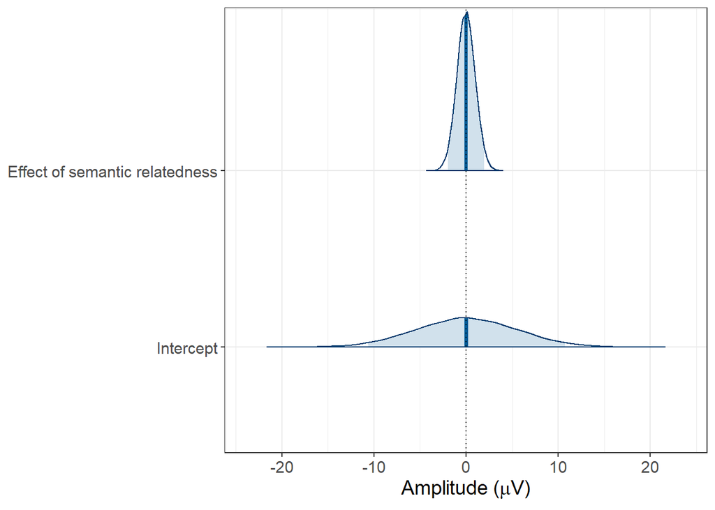

```r
#color_scheme_set("gray")
mcmc_areas(as.array(Priors1_check),
            pars = c("b_Intercept", "b_cond"),
            prob = .95,
            point_est = "mean") +
     labs(x = expression(paste("Amplitude (", mu,"V)"))) +
     theme_bw() +
     theme(text = element_text(size = 14)) +
     geom_vline(xintercept = 0, linetype = "dotted") +
     scale_y_discrete(limits = c("b_Intercept", "b_cond"),
                      breaks = c("b_Intercept", "b_cond"),
                      labels = c("Intercept", "Effect of semantic relatedness"))
```

Inspect prior predictive distribution

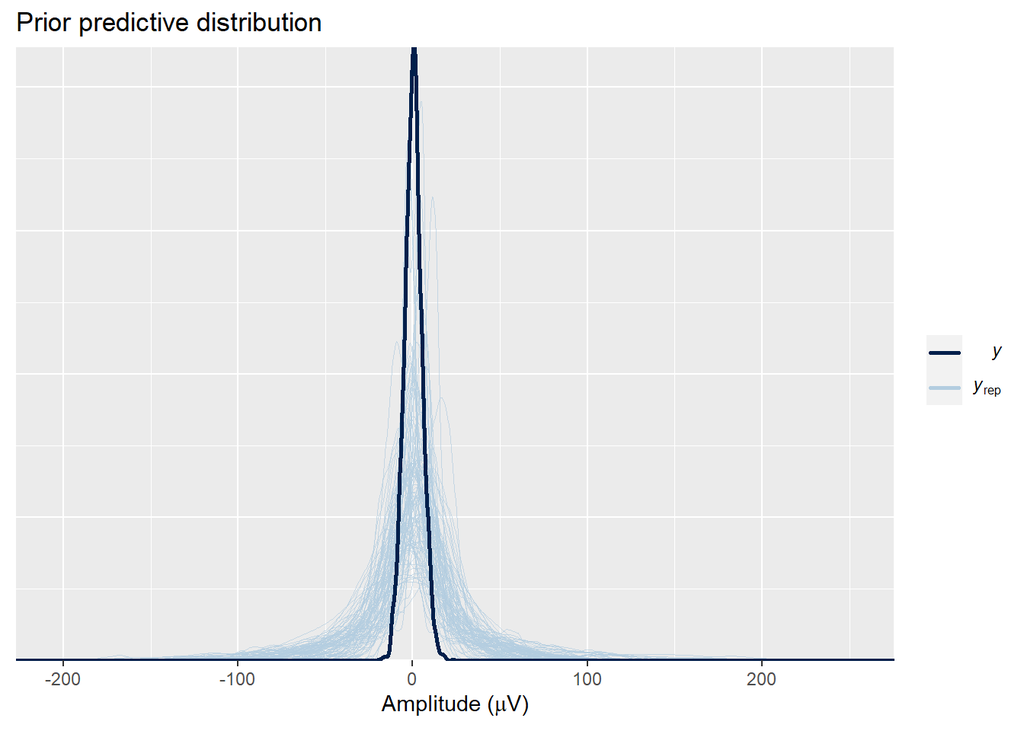

```r
# Compare distribution of y to distributions of multiple yrep datasets
pp_check(Priors1_check, ndraws = 100) +
  scale_x_continuous(expression(paste("Amplitude (", mu,"V)"))) +
  ggtitle("Prior predictive distribution")
```

Check mean, mix and max

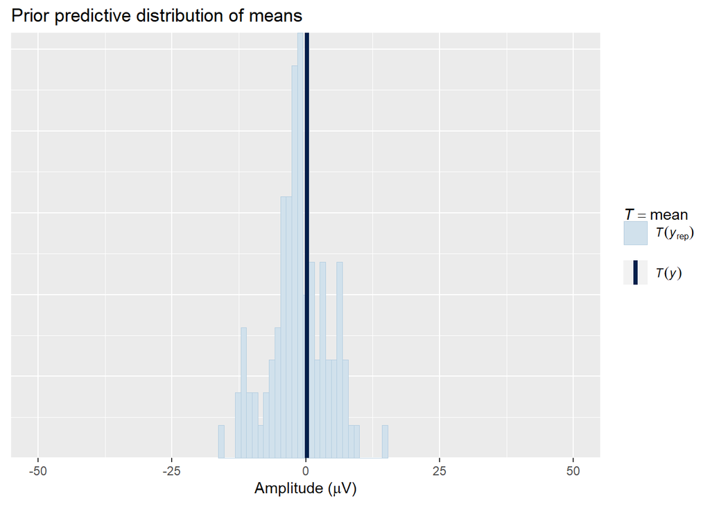

```r
#memory.limit(size = 56000)
pp_check(Priors1_check, type = "stat", stat = "mean", ndraws = 100) +
  coord_cartesian(xlim = c(-50,50)) +
  scale_x_continuous(expression(paste("Amplitude (", mu,"V)"))) +
  ggtitle("Prior predictive distribution of means")
```

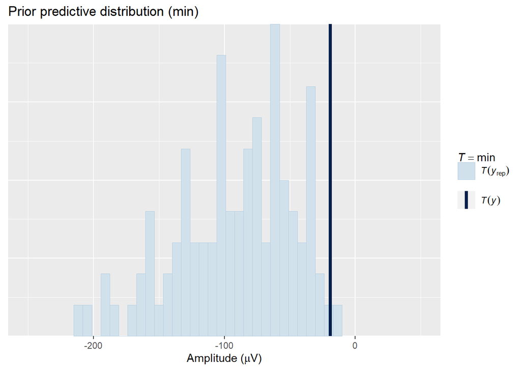

```r
pp_check(Priors1_check, type = "stat", stat = "min", ndraws = 100) +
  coord_cartesian(xlim = c(-250,50)) +
  scale_x_continuous(expression(paste("Amplitude (", mu,"V)"))) +
  ggtitle("Prior predictive distribution (min)")
```

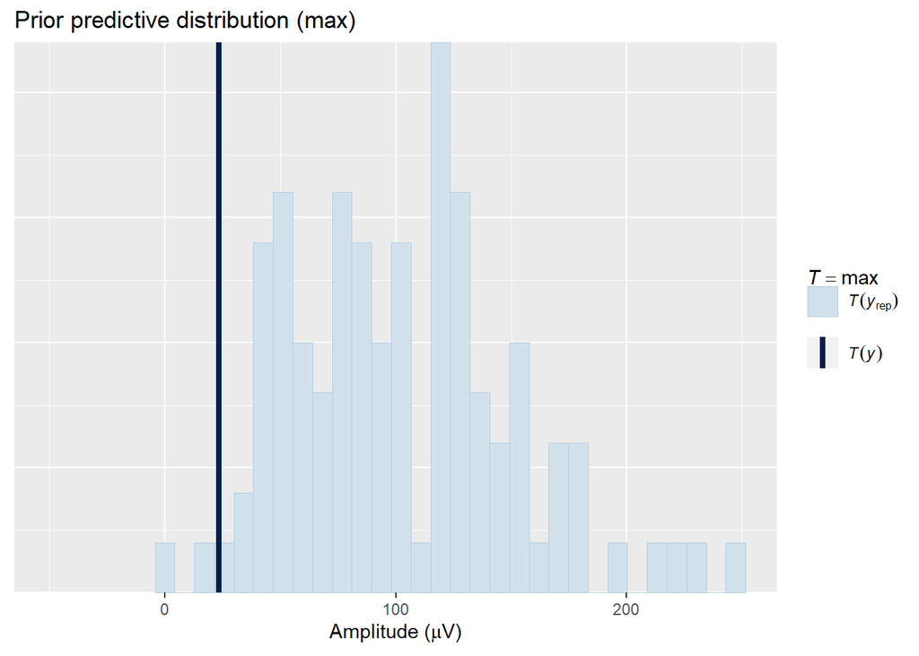

```r
pp_check(Priors1_check, type = "stat", stat = "max", ndraws = 100) +
  coord_cartesian(xlim = c(-50,250)) +
  scale_x_continuous(expression(paste("Amplitude (", mu,"V)"))) +
  ggtitle("Prior predictive distribution (max)")
```

## Fit the model

```r
m1 <- brm(AvgAmpl ~ 1 + cond + (1 + cond | Subj) + (1 + cond | Word),
             data = dataN4002,
             family = gaussian(),
             prior = priors1,
             warmup = 2000,
             iter = 10000,
             cores = 4,
             save_pars = save_pars(all = TRUE),
             control = list(adapt_delta = 0.99, max_treedepth = 15))

saveRDS(m1,"data_from_analysis/m1.RDS")
```

## Posterior fit and posterior predictive checks

Inspect Bulk ESS, tail ESS, R hat

- ESS is an estimate of the sample size required to achieve the same level of precision if that sample was a simple random sample (i.e., n independent samples)
- “how much independent information there is in autocorrelated chains” (Kruschke 2015, pp. 182-183)
- Schould be as large as possible, at least 1000

```r
m1
```

```
##  Family: gaussian
##   Links: mu = identity; sigma = identity
## Formula: AvgAmpl ~ 1 + cond + (1 + cond | Subj) + (1 + cond | Word)
##    Data: dataN4002 (Number of observations: 2561)
##   Draws: 4 chains, each with iter = 10000; warmup = 2000; thin = 1;
##          total post-warmup draws = 32000
##
## Group-Level Effects:
## ~Subj (Number of levels: 71)
##                     Estimate Est.Error l-95% CI u-95% CI Rhat Bulk_ESS Tail_ESS
## sd(Intercept)           1.25      0.17     0.93     1.62 1.00    15413    21868
## sd(cond)                0.13      0.06     0.01     0.25 1.00     4256     6652
## cor(Intercept,cond)     0.13      0.33    -0.47     0.78 1.00    15689    14984
##
## ~Word (Number of levels: 40)
##                     Estimate Est.Error l-95% CI u-95% CI Rhat Bulk_ESS Tail_ESS
## sd(Intercept)           0.95      0.18     0.64     1.33 1.00    13971    21370
## sd(cond)                0.07      0.05     0.00     0.19 1.00     7304    13625
## cor(Intercept,cond)    -0.00      0.40    -0.73     0.77 1.00    33390    22885
##
## Population-Level Effects:
##           Estimate Est.Error l-95% CI u-95% CI Rhat Bulk_ESS Tail_ESS
## Intercept     0.61      0.25     0.12     1.10 1.00    12953    20058
## cond         -0.19      0.04    -0.27    -0.10 1.00    40879    25372
##
## Family Specific Parameters:
##       Estimate Est.Error l-95% CI u-95% CI Rhat Bulk_ESS Tail_ESS
## sigma     4.79      0.07     4.66     4.93 1.00    46729    23489
##
## Draws were sampled using sampling(NUTS). For each parameter, Bulk_ESS
## and Tail_ESS are effective sample size measures, and Rhat is the potential
## scale reduction factor on split chains (at convergence, Rhat = 1).
```

Plot posterior densities and trace plots

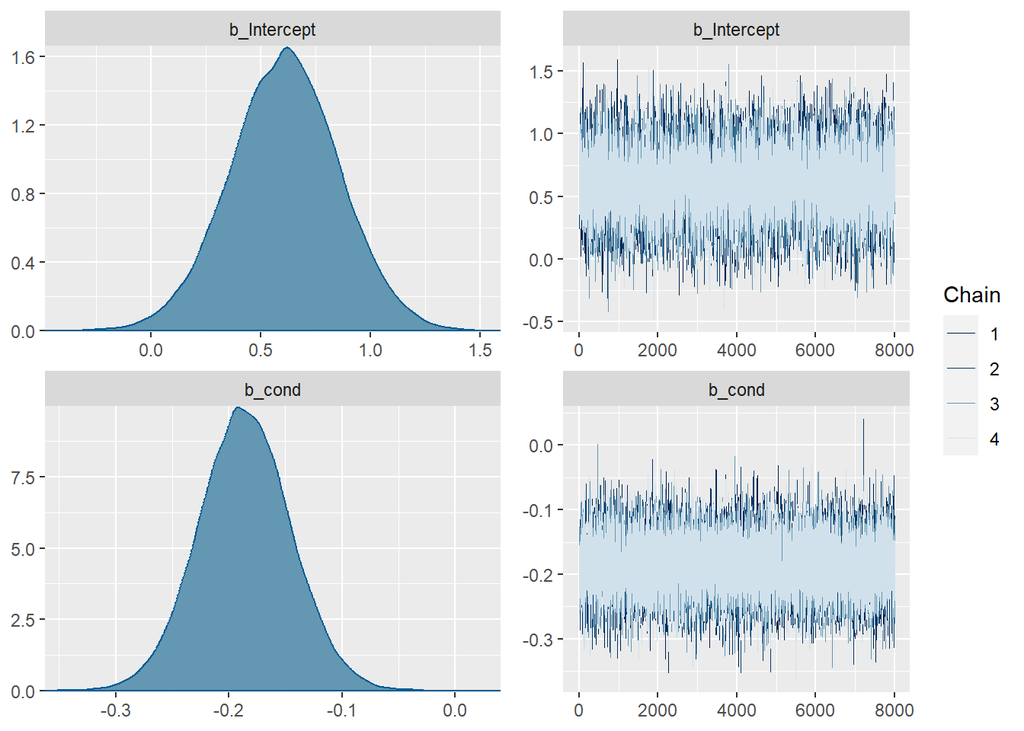

```r
m1_trace <- plot(m1, pars = "^b_")
```

```r
m1_trace <- do.call("plot_grid", c(m1_trace, nrow = 1))
```

Plot posterior distributions

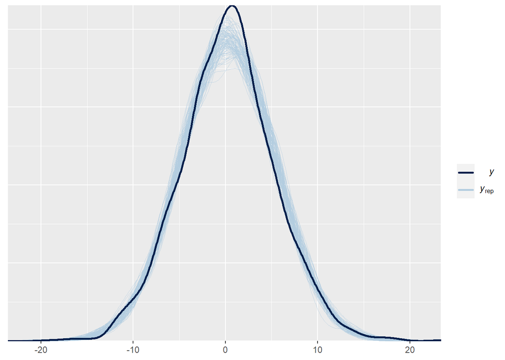

```r
pp_check(m1, ndraws = 100)
```

How well does the model capture the by-subject data pattern?

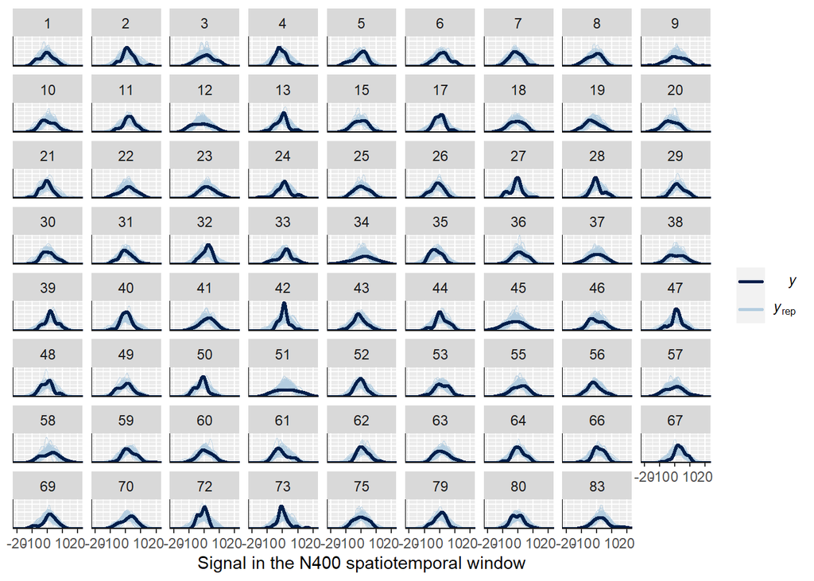

```r
ppc_dens_overlay_grouped(dataN400$AvgAmpl,
  yrep = posterior_predict(m1, ndraws = 100),
  group = dataN400$Subj) +
  xlab("Signal in the N400 spatiotemporal window")
```

Plot posterior distributions of the SDs per subject and compare them with the observed SDs

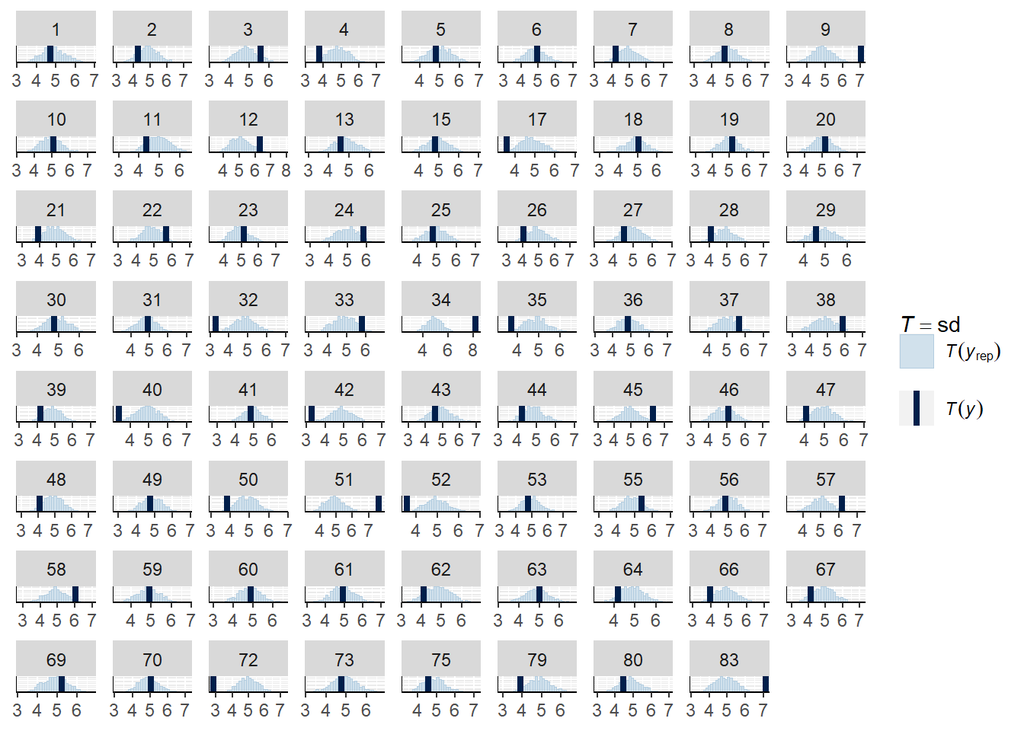

```r
pp_check(m1,
  type = "stat_grouped",
  ndraws = 1000,
  group = "Subj",
  stat = "sd")
```

It seems that the by-subject noise level is misfitted for some subjects. We can try and rectify this by using distributional regression and specifying random effects for the scale parameter, $\sigma$ (in addition to the location parameter, $\mu$).

# Define priors - DRM

Let’s add random-effects structure to $\sigma$, like so:

$$signal_{n} = Normal(\alpha + u_{subj[n],1} + w_{item[n],1} +
Cond_{n}*(\beta + u_{subj[n],2} + w_{item[n],2}), \sigma_{n})$$

where

$$\sigma_{n} = exp(\sigma_{\alpha} + \sigma_{u_{subj[n]}})$$

Note that the only reason we exponentiate is so that, if adjustments to $\sigma$ are negative, $\sigma$ itself does not become negative.

Now we need new priors for $\sigma$, too.

- $\sigma_{\alpha} \sim Normal(0, log(10))$
- $\sigma_{u} \sim Normal(0, \tau_{\sigma_{u}})$
- $\tau_{\sigma_{u}} \sim Normal_{+}(0, 5)$

Everything else stays the same!

In brms:

```r
priors1d <- c(set_prior("normal(0, 5)", class = "Intercept"),
            set_prior ("normal(0, 1)", class = "b"),
            set_prior ("normal(0, 5)", class = "sd"),
            set_prior ("lkj(2)", class = "cor"),
            set_prior ("normal(0, log(10))",
                       class = "Intercept", dpar = "sigma"),
            set_prior("normal(0,5)", class = "sd",
                      group = "Subj", dpar = "sigma"))
```

# Prior set 1 - DRM

## Prior predictive checks

Sample from priors

```r
Priors1d_check <- brm(bf(
  AvgAmpl ~ 1 + cond + (1 + cond | Subj) + (1 + cond | Word),
  sigma ~ 1 + (1 | Subj)),
             data = dataN400,
             family = gaussian(),
             prior = priors1d,
             warmup = 2000,
             iter = 10000,
             cores = 4,
             save_pars = save_pars(all = TRUE),
             control = list(adapt_delta = 0.99, max_treedepth = 15),
             sample_prior = "only")

saveRDS(Priors1d_check,"data_from_analysis/priors1d_check.RDS")
```

Visualise priors

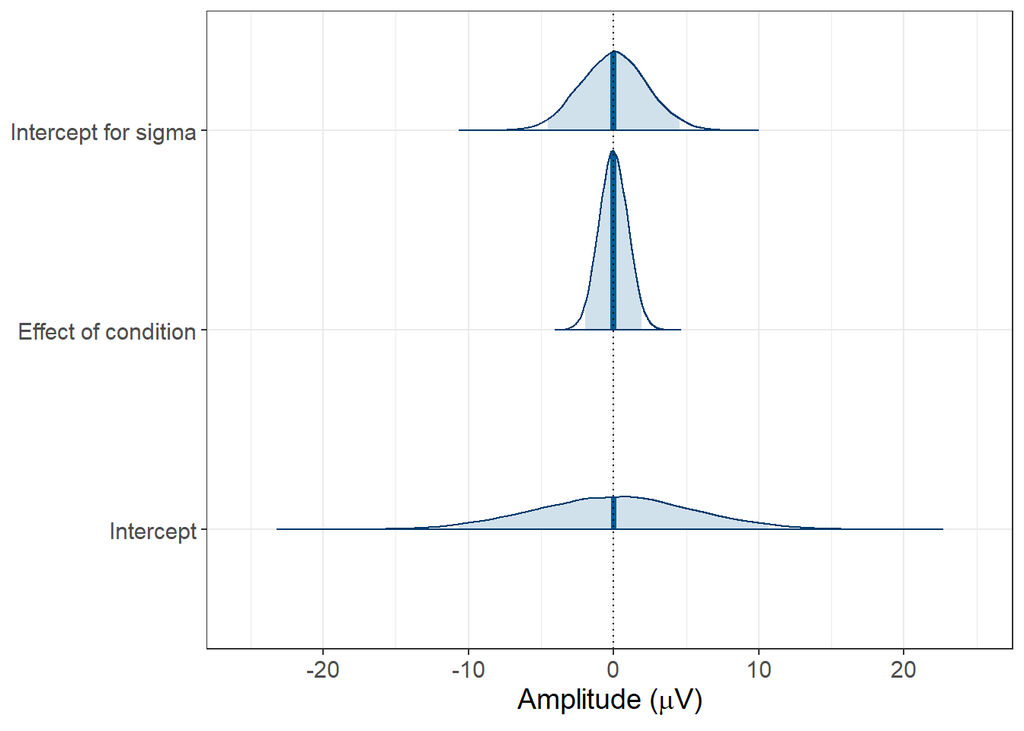

```r
mcmc_areas(as.array(Priors1d_check),
            pars = c("b_Intercept", "b_cond", "b_sigma_Intercept"),
            prob = .95,
            point_est = "mean") +
     labs(x = expression(paste("Amplitude (", mu,"V)"))) +
     theme_bw() +
     theme(text = element_text(size = 14)) +
     geom_vline(xintercept = 0, linetype = "dotted") +
     scale_y_discrete(limits = c("b_Intercept", "b_cond", "b_sigma_Intercept"),
                      breaks = c("b_Intercept", "b_cond", "b_sigma_Intercept"),
                      labels = c("Intercept", "Effect of condition", "Intercept for sigma"))
```

## Fit the model

```r
m1d <- brm(bf(
  AvgAmpl ~ 1 + cond + (1 + cond | Subj) + (1 + cond | Word),
  sigma ~ 1 + (1 | Subj)),
             data = dataN400,
             family = gaussian(),
             prior = priors1d,
             warmup = 2000,
             iter = 10000,
             cores = 4,
             save_pars = save_pars(all = TRUE),
             control = list(adapt_delta = 0.99, max_treedepth = 15))

saveRDS(m1d,"data_from_analysis/m1d.RDS")
```

## Posterior fit and posterior predictive checks

```r
m1d
```

```
##  Family: gaussian
##   Links: mu = identity; sigma = log
## Formula: AvgAmpl ~ 1 + cond + (1 + cond | Subj) + (1 + cond | Word)
##          sigma ~ 1 + (1 | Subj)
##    Data: dataN4002 (Number of observations: 2561)
##   Draws: 4 chains, each with iter = 10000; warmup = 2000; thin = 1;
##          total post-warmup draws = 32000
##
## Group-Level Effects:
## ~Subj (Number of levels: 71)
##                     Estimate Est.Error l-95% CI u-95% CI Rhat Bulk_ESS Tail_ESS
## sd(Intercept)           1.24      0.17     0.92     1.60 1.00    14231    20524
## sd(cond)                0.13      0.06     0.01     0.25 1.00     4118     7061
## sd(sigma_Intercept)     0.16      0.02     0.12     0.21 1.00    13305    22429
## cor(Intercept,cond)     0.10      0.32    -0.49     0.74 1.00    17253    16933
##
## ~Word (Number of levels: 40)
##                     Estimate Est.Error l-95% CI u-95% CI Rhat Bulk_ESS Tail_ESS
## sd(Intercept)           0.91      0.17     0.61     1.28 1.00    13113    20317
## sd(cond)                0.06      0.04     0.00     0.16 1.00     8847    15777
## cor(Intercept,cond)     0.00      0.41    -0.76     0.78 1.00    37467    23469
##
## Population-Level Effects:
##                 Estimate Est.Error l-95% CI u-95% CI Rhat Bulk_ESS Tail_ESS
## Intercept           0.59      0.24     0.11     1.06 1.00    13810    20302
## sigma_Intercept     1.54      0.02     1.50     1.59 1.00    15950    20578
## cond               -0.19      0.04    -0.26    -0.11 1.00    38435    25726
##
## Draws were sampled using sampling(NUTS). For each parameter, Bulk_ESS
## and Tail_ESS are effective sample size measures, and Rhat is the potential
## scale reduction factor on split chains (at convergence, Rhat = 1).
```

Plot posterior densities and trace plots

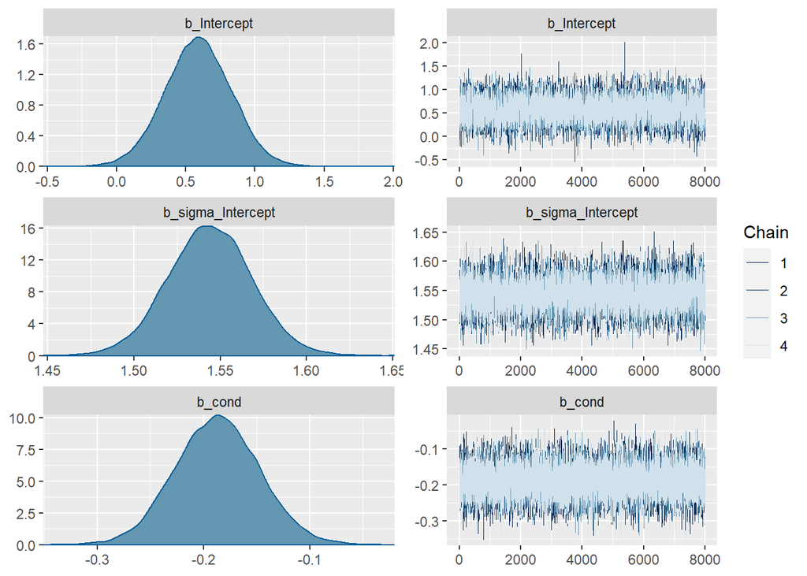

```r
m1d_trace <- plot(m1d, pars = "^b_")
```

```r
m1d_trace <- do.call("plot_grid", c(m1d_trace, nrow = 1))
```

Plot posterior distributions

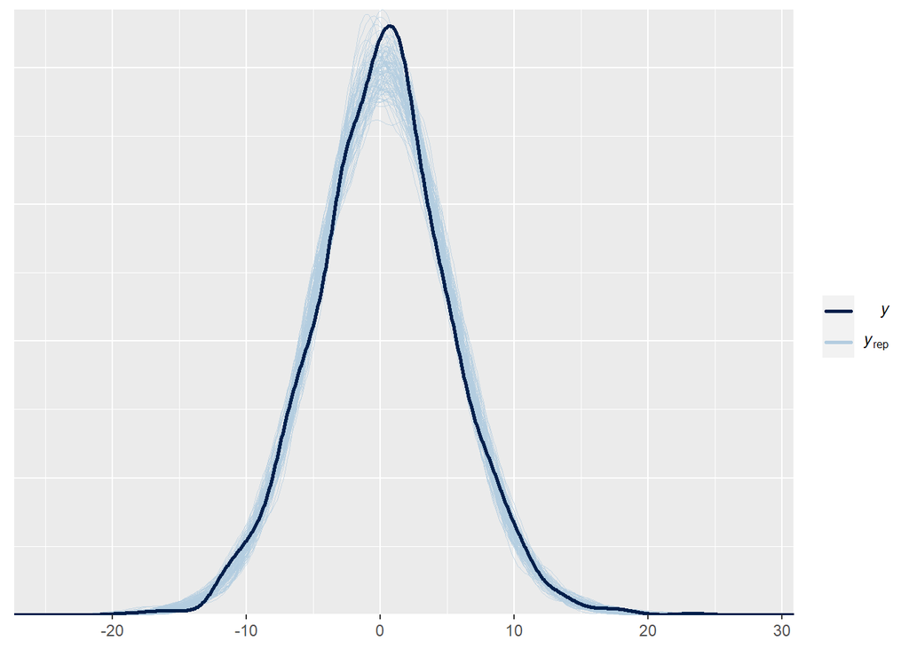

```r
pp_check(m1d, ndraws = 100)
```

How well does the model capture the by-subject data pattern?

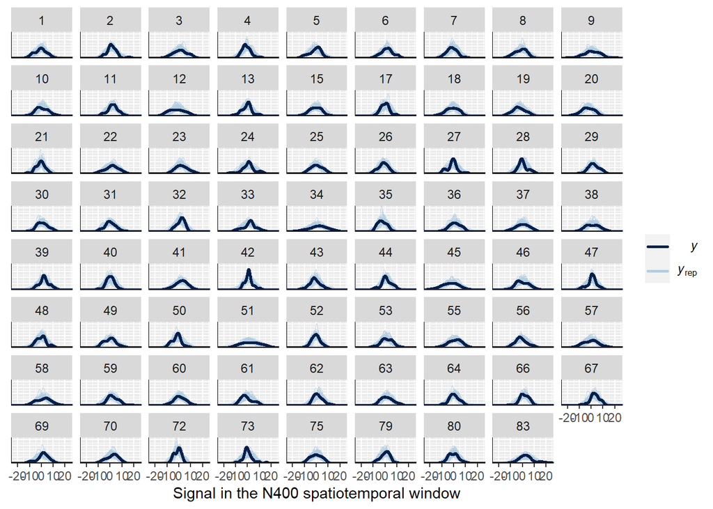

```r
ppc_dens_overlay_grouped(dataN400$AvgAmpl,
  yrep = posterior_predict(m1d, ndraws = 100),
  group = dataN400$Subj) +
  xlab("Signal in the N400 spatiotemporal window")
```

Plot posterior distributions of the SDs per subject and compare them with the observed SDs

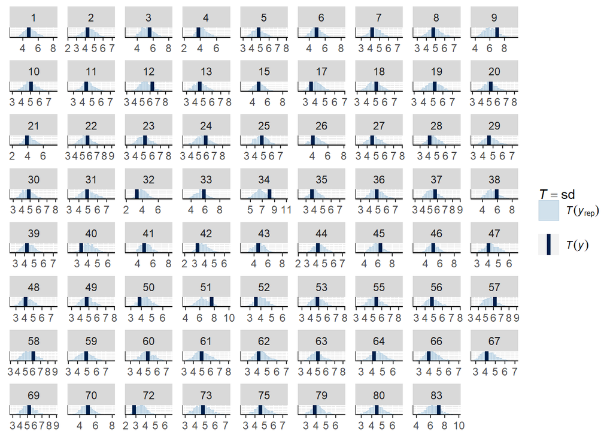

```r
pp_check(m1d,
  type = "stat_grouped",
  ndraws = 1000,
  group = "Subj",
  stat = "sd")
```

## Summarise model

```r
round(fixef(m1d),3)
```

```
##                 Estimate Est.Error   Q2.5  Q97.5
## Intercept          0.589     0.241  0.115  1.058
## sigma_Intercept    1.544     0.024  1.496  1.592
## cond              -0.187     0.040 -0.265 -0.108
```

Plot mean effect of semantic relatedness

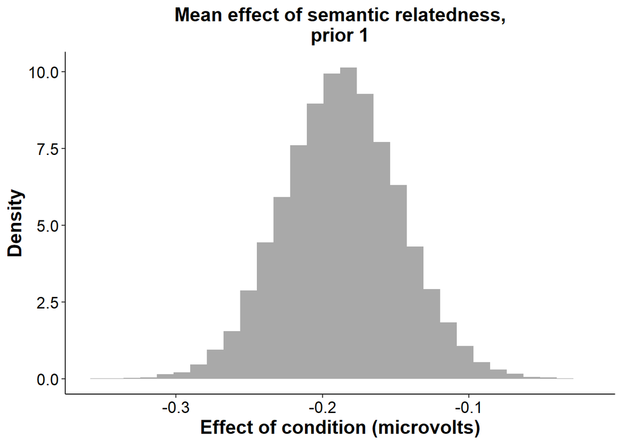

```r
cond1_d <- posterior_samples(m1d)$b_cond
ggplot(as.data.frame(cond1_d), aes(x = cond1_d)) +
  geom_histogram(aes(y = ..density..), fill = "darkgray") +
  theme_classic() +
  ylab("Density") +
  xlab("Effect of condition (microvolts)") +
  ggtitle("Mean effect of semantic relatedness,\nprior 1") +
  theme(axis.title.x = element_text(size = rel(1.4),
                                    colour = "black", face = "bold"),
        axis.title.y = element_text(size = rel(1.4),
                                    colour = "black", face = "bold"),
        panel.background = element_rect(colour = "white"),
        axis.text = element_text(size = rel(1.2), colour = "black"),
        legend.text = element_text(size = rel(1.2), colour = "black"),
        legend.title = element_text(size = rel(1.4),
                                    colour = "black", face = "bold"),
        plot.title = element_text(size = rel(1.4),
                                  face = "bold", hjust = 0.5),
        axis.line = element_line(colour = "black"))
```

Uncertainty intervals computed from posterior draws

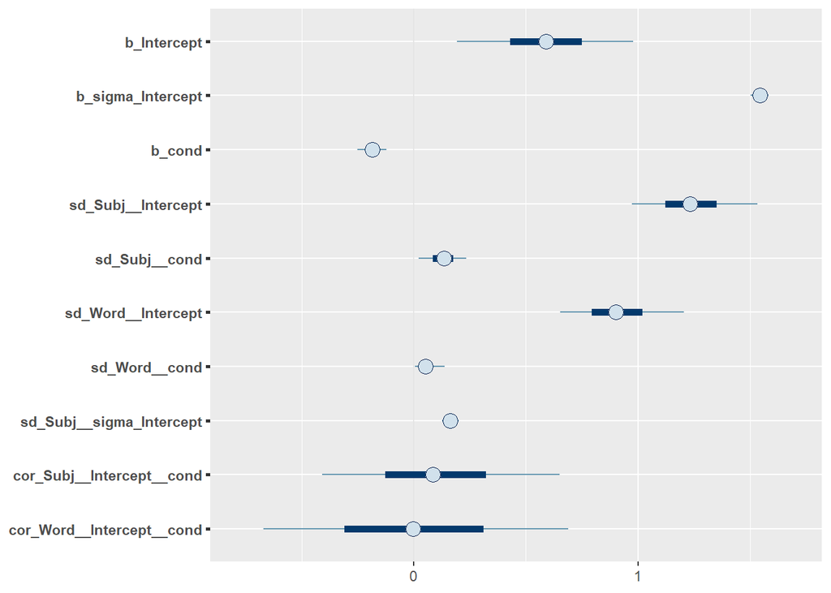

```r
mcmc_plot(m1d, type = "intervals")
```

Density plot (uncertainty intervals shown as shaded areas under the curves)

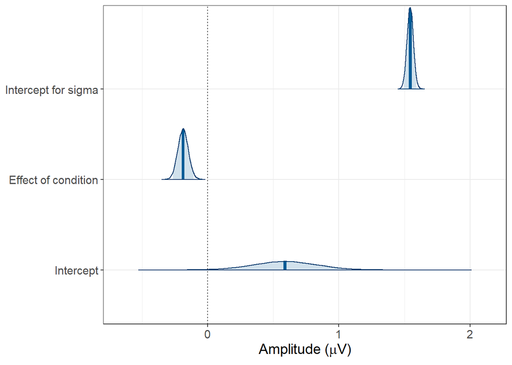

```r
mcmc_areas(as.array(m1d),
            pars = c("b_Intercept", "b_cond", "b_sigma_Intercept"),
            prob = .95,
            point_est = "mean") +
    labs(x = expression(paste("Amplitude (", mu,"V)"))) +
    theme_bw() +
    theme(text = element_text(size = 14)) +
    geom_vline(xintercept = 0, linetype = "dotted") +
    scale_y_discrete(limits = c("b_Intercept", "b_cond", "b_sigma_Intercept"),
                   breaks = c("b_Intercept", "b_cond", "b_sigma_Intercept"),
                   labels = c("Intercept" ,"Effect of condition", "Intercept for sigma"))
```

Compare prior and posterior probabilities

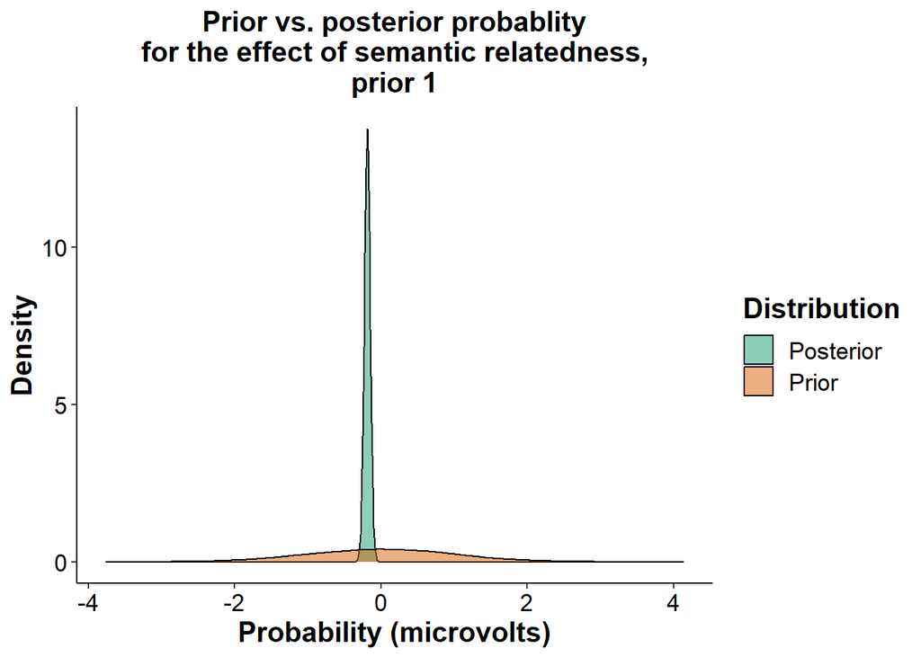

```r
# generate samples from the prior:
N <- length(cond1_d)
sample_cond_prior <- rnorm(N, 0, 1)
samples <- tibble(
  sample = c(cond1_d, sample_cond_prior),
  distribution = c(rep("Posterior", N), rep("Prior", N)))

ggplot(samples, aes(x = sample, fill = distribution)) +
  geom_density(alpha = .5) + theme_classic() +
  ylab("Density") +
  xlab("Probability (microvolts)") +
  ggtitle("Prior vs. posterior probablity\nfor the effect of semantic relatedness,\nprior 1") +
  theme(axis.title.x = element_text(size = rel(1.4),
                                    colour = "black", face = "bold"),
        axis.title.y = element_text(size = rel(1.4),
                                    colour = "black", face = "bold"),
        panel.background = element_rect(colour = "white"),
        axis.text = element_text(size = rel(1.2), colour = "black"),
        legend.text = element_text(size = rel(1.2), colour = "black"),
        legend.title = element_text(size = rel(1.4),
                                    colour = "black", face = "bold"),
        plot.title = element_text(size = rel(1.4),
                                  face = "bold", hjust = 0.5),
        axis.line = element_line(colour = "black")) +
  labs(fill = "Distribution") +
  scale_fill_brewer(palette = "Dark2")
```

## Fit null model

```r
m1d_null <- brm(bf(
  AvgAmpl ~ 1 + (1 + cond | Subj) + (1 + cond | Word),
  sigma ~ 1 + (1 | Subj)),
             data = dataN400,
             family = gaussian(),
             prior = priors1d[-2,],
             warmup = 2000,
             iter = 10000,
             cores = 4,
             save_pars = save_pars(all = TRUE),
             control = list(adapt_delta = 0.99, max_treedepth = 15))

saveRDS(m1d_null,"data_from_analysis/m1d_null.RDS")
```

At this point you should do the same model diagnostics as those shown above…

## Estimate BF

### Compute marginal likelihoods

Model of interest

```r
m1d_ml <- bridge_sampler(m1d, silent = TRUE)
saveRDS(m1d_ml,"data_from_analysis/m1d_ml.RDS")
```

Null model

```r
m1d_null_ml <- bridge_sampler(m1d_null, silent = TRUE)
saveRDS(m1d_null_ml,"data_from_analysis/m1d_null_ml.RDS")
```

### Compute BF

```r
bf1 <- bayes_factor(m1d_ml, m1d_null_ml)
```

```r
bf1$bf
```

```
## [1] 693.6825
```

```r
1/bf1$bf
```

```
## [1] 0.001441582
```

# Next steps

You should now fit the models (model of interest and the null model) with the other two sets of priors and compute Bayes factors. You can then compare whether the BFs have changed depending on the prior on the effect of semantic relatedness.

# Bonus

[See here](https://osf.io/8mj5n) for one way to analyse RT data with Bayesian LMMs.